# Homework5

### Part 1 Analysis the Wolfe Primates

These data represent 3 months of interactions among a troop of monkeys, observed in the wild by Linda Wolfe as they sported by a river in Ocala, Florida. Joint presence at the river was coded as an interaction and these were summed within all pairs.

There are two files for the data. `labels.csv` is the file contains information for each monkey, with their genders, ages and their rank in the troop. `link_m.csv` is the file contains the number of their interaction in the adjacency matrix format.

Note: when load the `link_m.csv`, set the header to be none.

#### Part 1.1 Visualize the adjacency matrix (10 points)

Load the data and re-arrange the link matrix with the rank. For example, if the original data is:

|  | ID | Sex | Age | Rank |
| --- | --- | --- | --- | --- |
| 0 | 1 | female | 12 | 3 |
| 1 | 2 | male | 9 | 2 |
| 2 | 3 | male | 15 | 1 |
| 3 | 4 | male | 7 | 5 |
| 4 | 5 | female | 4 | 4 |

Then in the link_m, you need to re-order both rows and columns of the matrix with the order [3,2,1,5,4]. However, you also need to minus one on the index since the starting index in the matrix is 0 while the starting index in the rank is 1.

Then use the following code to get the data visualization for the adjacency matrix.

```
plt.imshow(link_m, cmap='binary', interpolation='none')
```

Give title and labels for the plot.

```python
import pandas as pd
import numpy as np
import matplotlib.pyplot as plt
import networkx as nx
from pyvis.network import Network
```

```python
# Load the data
labels_df = pd.read_csv('labels.csv')
link_matrix = pd.read_csv('link_m.csv', header = None)
```

```python
labels_df.head(5)
```

|  | Id | Sex | Age | Rank |
| --- | --- | --- | --- | --- |
| 0 | 1 | male | 15 | 1 |
| 1 | 2 | male | 10 | 2 |
| 2 | 3 | male | 10 | 3 |
| 3 | 4 | male | 8 | 4 |
| 4 | 5 | male | 7 | 5 |

```python
link_matrix
```

|  | 0 | 1 | 2 | 3 | 4 | 5 | 6 | 7 | 8 | 9 | 10 | 11 | 12 | 13 | 14 | 15 | 16 | 17 | 18 | 19 |
| --- | --- | --- | --- | --- | --- | --- | --- | --- | --- | --- | --- | --- | --- | --- | --- | --- | --- | --- | --- | --- |
| 0 | 0 | 2 | 10 | 4 | 5 | 5 | 9 | 7 | 4 | 3 | 3 | 7 | 3 | 2 | 5 | 1 | 4 | 1 | 0 | 1 |
| 1 | 2 | 0 | 5 | 1 | 3 | 1 | 4 | 2 | 6 | 2 | 5 | 4 | 3 | 2 | 2 | 6 | 3 | 1 | 1 | 1 |
| 2 | 10 | 5 | 0 | 8 | 9 | 5 | 11 | 7 | 8 | 8 | 14 | 17 | 9 | 11 | 11 | 5 | 9 | 4 | 6 | 5 |
| 3 | 4 | 1 | 8 | 0 | 4 | 0 | 3 | 4 | 2 | 3 | 5 | 3 | 11 | 4 | 7 | 0 | 4 | 3 | 3 | 0 |
| 4 | 5 | 3 | 9 | 4 | 0 | 3 | 5 | 7 | 4 | 3 | 5 | 6 | 3 | 4 | 4 | 1 | 2 | 1 | 3 | 3 |
| 5 | 5 | 1 | 5 | 0 | 3 | 0 | 5 | 2 | 3 | 2 | 2 | 4 | 4 | 3 | 1 | 1 | 2 | 0 | 1 | 2 |
| 6 | 9 | 4 | 11 | 3 | 5 | 5 | 0 | 5 | 4 | 6 | 3 | 9 | 5 | 5 | 4 | 2 | 6 | 3 | 2 | 2 |
| 7 | 7 | 2 | 7 | 4 | 7 | 2 | 5 | 0 | 3 | 0 | 3 | 4 | 2 | 1 | 3 | 0 | 1 | 1 | 1 | 0 |
| 8 | 4 | 6 | 8 | 2 | 4 | 3 | 4 | 3 | 0 | 1 | 3 | 2 | 4 | 5 | 4 | 3 | 4 | 1 | 3 | 2 |
| 9 | 3 | 2 | 8 | 3 | 3 | 2 | 6 | 0 | 1 | 0 | 4 | 7 | 5 | 5 | 7 | 2 | 2 | 3 | 3 | 2 |
| 10 | 3 | 5 | 14 | 5 | 5 | 2 | 3 | 3 | 3 | 4 | 0 | 9 | 3 | 4 | 4 | 2 | 4 | 2 | 3 | 1 |
| 11 | 7 | 4 | 17 | 3 | 6 | 4 | 9 | 4 | 2 | 7 | 9 | 0 | 7 | 7 | 8 | 3 | 7 | 2 | 4 | 3 |
| 12 | 3 | 3 | 9 | 11 | 3 | 4 | 5 | 2 | 4 | 5 | 3 | 7 | 0 | 8 | 11 | 3 | 8 | 2 | 5 | 3 |
| 13 | 2 | 2 | 11 | 4 | 4 | 3 | 5 | 1 | 5 | 5 | 4 | 7 | 8 | 0 | 8 | 1 | 5 | 4 | 4 | 1 |
| 14 | 5 | 2 | 11 | 7 | 4 | 1 | 4 | 3 | 4 | 7 | 4 | 8 | 11 | 8 | 0 | 2 | 5 | 2 | 2 | 1 |
| 15 | 1 | 6 | 5 | 0 | 1 | 1 | 2 | 0 | 3 | 2 | 2 | 3 | 3 | 1 | 2 | 0 | 6 | 1 | 0 | 1 |
| 16 | 4 | 3 | 9 | 4 | 2 | 2 | 6 | 1 | 4 | 2 | 4 | 7 | 8 | 5 | 5 | 6 | 0 | 4 | 3 | 3 |
| 17 | 1 | 1 | 4 | 3 | 1 | 0 | 3 | 1 | 1 | 3 | 2 | 2 | 2 | 4 | 2 | 1 | 4 | 0 | 2 | 1 |
| 18 | 0 | 1 | 6 | 3 | 3 | 1 | 2 | 1 | 3 | 3 | 3 | 4 | 5 | 4 | 2 | 0 | 3 | 2 | 0 | 6 |
| 19 | 1 | 1 | 5 | 0 | 3 | 2 | 2 | 0 | 2 | 2 | 1 | 3 | 3 | 1 | 1 | 1 | 3 | 1 | 6 | 0 |

```python
# Get rank order (subtract 1 for 0-based indexing)
rank_order = labels_df['Rank'].values - 1

# Reorder matrix based on ranks
reorder_link_m = link_matrix.iloc[rank_order, rank_order]
```

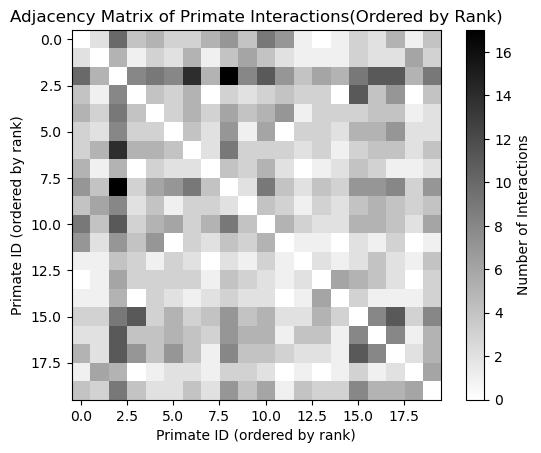

```python
# Create visualization
plt.imshow(reorder_link_m, cmap = 'binary', interpolation = 'none')
plt.colorbar(label = 'Number of Interactions')
plt.title('Adjacency Matrix of Primate Interactions(Ordered by Rank)')
plt.xlabel('Primate ID (ordered by rank)')
plt.ylabel('Primate ID (ordered by rank)')
plt.show()
```

#### Part 1.2 edgelist (10 points)

Convert the data into a edgelist data frame with three columns: source, target and weight.

```python
# Convert matrix to edgelist
edges = []
n = len(link_matrix)
for i in range(n):
    for j in range(n):
        if link_matrix.iloc[i, j] > 0:
            edges.append({
                'source': i,
                'target': j,
                'weight': link_matrix.iloc[i, j]
            })

edgelist_df = pd.DataFrame(edges)
```

```python
# Display Result
print("\nFirst few rows of edgelist:")
print(edgelist_df.head())

print("\nEdgelist information:")
print(f"Total number of edges: {len(edgelist_df)}")
```

```
First few rows of edgelist:
   source  target  weight
0       0       1       2
1       0       2      10
2       0       3       4
3       0       4       5
4       0       5       5

Edgelist information:
Total number of edges: 362
```

#### Part 1.3 Make a static network (15 points)

Use the edgelist generated from part 1.2, make a bipartite network, such that one side is for male and the other side is for female. The colors of the nodes are decided by the gender. The sizes of the nodes are decided by the age. The width of the edges are decided by the weight.

```python
# Create graph
G = nx.Graph()

# Add nodes with attributes
for idx, row in labels_df.iterrows():
    G.add_node(idx, sex = row['Sex'])

# Add edges from edgelist df
for _, row in edgelist_df.iterrows():
    G.add_edge(int(row['source']), int(row['target']), weight = row['weight'])

# Separate males and females for bipartite layout
male_nodes = [n for n in G.nodes() if labels_df.loc[n, 'Sex'] == 'male']
female_nodes = [n for n in G.nodes() if labels_df.loc[n, 'Sex'] == 'female']
```

```python
# Create position dictionary for bipartite layout
pos = {}

# Position males on left, females on right
male_y = np.linspace(0, 1, len(male_nodes))
female_y = np.linspace(0, 1, len(female_nodes))

for i, node in enumerate(male_nodes):
    pos[node] = (-1, male_y[i])

for i, node in enumerate(female_nodes):
    pos[node] = (1, female_y[i])
```

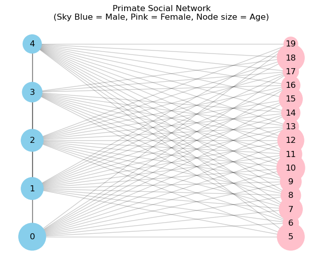

```python
# Create visualization
# Draw the network
plt.figure(figsize = (8, 6))
nx.draw_networkx_edges(G, pos, alpha = 0.2)

# Draw male and female nodes
nx.draw_networkx_nodes(G, pos, nodelist = male_nodes, node_color = 'skyblue',
                      node_size = [labels_df.loc[n, 'Age'] * 100 for n in male_nodes])

nx.draw_networkx_nodes(G, pos, nodelist = female_nodes, node_color = 'pink',
                      node_size = [labels_df.loc[n, 'Age'] * 100 for n in female_nodes])

# Add node labels
nx.draw_networkx_labels(G, pos)

# Add title and display the visualization
plt.title("Primate Social Network\n(Sky Blue = Male, Pink = Female, Node size = Age)")
plt.axis('off')
plt.show()
```

#### Part 1.4 Make an interactive network (15 points)

Now make an interactive network use the same data. No need to maintain the bipartite layout but still colors, sizes and width to customize gender, age and weights. Save the html file and submit it with the Jupyter notebook.

```python
# Create a network
net = Network(notebook = True, height = "550px", width = "100%", bgcolor = "white", font_color = "black")

# Set physics layout options for better visualization
net.force_atlas_2based()
net.show_buttons(filter_ = ['physics'])
```

```python
# Add nodes with color and size
for idx, row in labels_df.iterrows():
    color = 'skyblue' if row['Sex'] == 'male' else 'pink'
    size = row['Age'] * 5
    title = f"ID: {idx}<br>Gender: {row['Sex']}<br>Age: {row['Age']}"
    net.add_node(idx, label = str(idx), color = color, size = size, title = title)
```

```python
# Add edges with widths using weight
for _, row in edgelist_df.iterrows():
    width = 0.1 + (row['weight'] / edgelist_df['weight'].max()) * 3
    title = f"Weight: {row['weight']}"
    net.add_edge(int(row['source']), int(row['target']), width = width, title = title)
```

```python
# Save the network
net.save_graph("interactive_network.html")
```

### Part 2 Design your own social network (30 points)

Now, let's try to visualize your own social network.

- Open an excel file.
- Set up an adjacency matrix for at least 10 people you know (not including yourself)
- Label the adjacency matrix based on your knowledge whether they know each other or not (You can just use 0/1 to indicate whether they know each other or not)
- Load the adjacency matrix to the Jupyter Notebook
- Convert then data to edgelist
- Plot the static network for your social network
- Now, include yourself into the network, plot the network again
- Discuss what you have seen in two networks and is there a specific layout you have chosen for your network.

```python
# Load the adjacency matrix
adj_matrix = pd.read_csv('my_network.csv', index_col = 0)

# Convert adjacency matrix to edge list
edges = []
for i in adj_matrix.index:
    for j in adj_matrix.columns:
        if adj_matrix.loc[i, j] == 1:
            edges.append((i, j))

# Create original network
G = nx.Graph()
G.add_edges_from(edges)
```

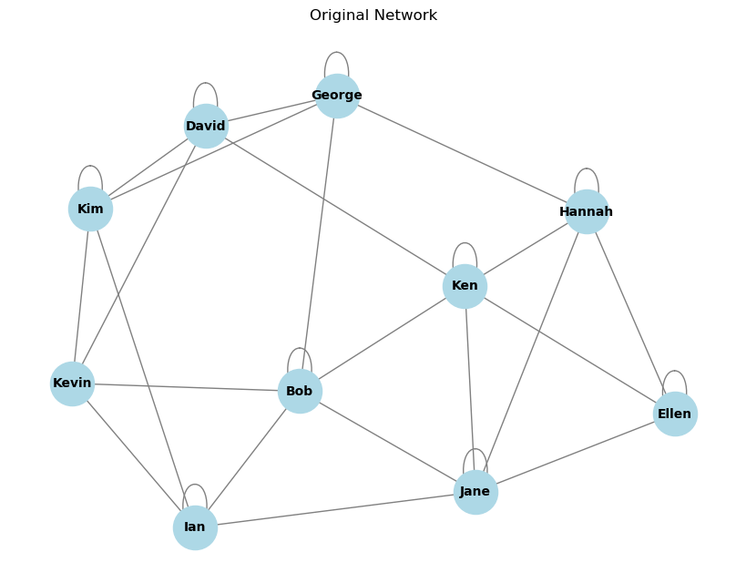

```python
# Plot the original network
plt.figure(figsize = (8, 6))
pos = nx.spring_layout(G)
nx.draw(G, pos,
        with_labels = True,
        node_color = 'lightblue',
        node_size = 1200,
        font_size = 10,
        font_weight = 'bold',
        edge_color = 'gray')
plt.title("Original Network")
plt.show()
```

```python
# Add my connection with these network
my_connections = ['Kevin', 'Bob', 'Ellen', 'Kim', 'Jane', 'Ian']
updated_edges = edges.copy()
for connection in my_connections:
    updated_edges.append(('ME', connection))

# create network include me
G_with_me = nx.Graph()
G_with_me.add_edges_from(updated_edges)
```

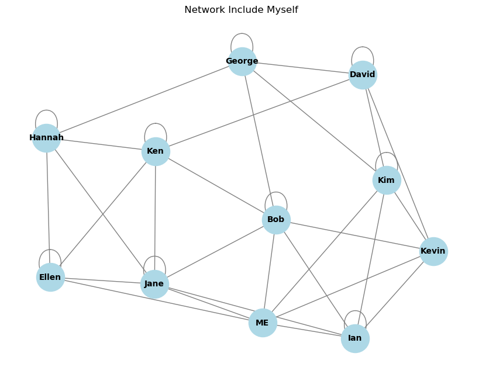

```python
# Plot the network include me
plt.figure(figsize = (8, 6))
pos_new = nx.spring_layout(G_with_me)
nx.draw(G_with_me, pos_new,
        with_labels = True,
        node_color = 'lightblue',
        node_size = 1200,
        font_size = 10,
        font_weight = 'bold',
        edge_color = 'gray')
plt.title(" Network Include Myself")
plt.show()
```

### Explanation

For both network visualisations, I use spring layouts, which can limit edge crossing, distribute space evenly for each node, and help to show a more natural cluster structure that makes the overall visualization easier to appeal and interprete for the audience. This is effective because it shows the grouping for network clearly, emphasis structure change before and after introducing myself into the network, and more importantly have better readability.

### Part 3 In-class activities in information presentation lecture

Write a paragraph about the importance of data visualization in data analysis (about 100 words). Then identify the logic flow in your writing.

### Importance of Data Visualization in Data Analysis

Data analysis is an essential tool to help transfer raw data into a visual representation for the audience to understand a topic better. It uses graphs, charts, and matrices to reveal patterns, trends, and anomalies that is hidden. While data visualization helps simplify complex relationships among data, the analyst could better tell their finding to diverse audiences like the decision-maker, general public, etc. Well-designed visualizations can support better decision-making by presenting insights clearly and succinctly. By addressing the gap between data information complexity and people's cognition, visualization allows analysts to make stronger conclusions and share their insights compellingly and engagingly.

### Explanation logic flow

I follow the 4 principle for the whole logic of this paragraph. The content focuses on the central idea that data visualization plays an important role in turning data into meaningful information that makes it essential in data analysis **(central contribution)**. In this case, I am targeting a **general audience** with little or no previous knowledge of the topic, and I am using simple and clear content to ensure that everyone can understand it. In addition, the writing follows a logical structure, starting with why visualisation is important, then explaining how it helps us see the pattern and trend, and ending with how it supports a better decision-making process **(C-C-C scheme)**. The ideas flow smoothly without jumping back and forth, and a parallel sentence structure makes it easy to follow. This approach helps ensure clarity and keeps the focus on the central idea **(logic flow)** .